# MAFDash

#### View examples on [github.io](https://mtandon09.github.io/MAFDash/)

# How to get help for MAFDash

Please post all the questions or queries related to MAFDash package on **Github Issues**. This will help us to build an information repository which can be used by other users.

https://github.com/ashishjain1988/MAFDash/issues

# Getting started

## Installation from CRAN

`install.packages("MAFDash")`

## Installation from Github

```r
install.packages(c("dplyr","ensurer","ggplot2","tidyr","DT","rmarkdown","knitr","flexdashboard","htmltools","data.table","ggbeeswarm","RColorBrewer","plotly","circlize","canvasXpress","crosstalk","bsplus","BiocManager","maftools","ComplexHeatmap"))
BiocManager::install(c("TCGAbiolinks"))
install.packages(devtools)
library(devtools)
devtools::install_github("ashishjain1988/MAFDashRPackage")
```

# Scope

[Mutation Annotation Format (MAF)](https://docs.gdc.cancer.gov/Encyclopedia/pages/Mutation_Annotation_Format/) is a tabular data format used for storing genetic mutation data. For example, [The Cancer Genome Atlas (TCGA)](https://www.cancer.gov/about-nci/organization/ccg/research/structural-genomics/tcga) project has made MAF files from each project publicly available.

The package – **MAFDash** – contains a set of R tools to easily create an HTML dashboard to summarize and visualize data from MAF file.

The resulting HTML file serves as a self-contained report that can be used to explore the result. Currently, MAFDash produces mostly static plots powered by [maftools](https://bioconductor.org/packages/release/bioc/vignettes/maftools/inst/doc/maftools.html), ComplexHeatmap and circlize, as well as interactive visualizations using canvasXpress and [plotly](https://plotly.com/r/). The report is generated with a parameterized [R Markdown](https://rmarkdown.rstudio.com/) script that uses [flexdashboard](https://rmarkdown.rstudio.com/flexdashboard/) to arrange all the information.

This package is a companion to the Shiny app, [MAFWiz](https://github.com/mtandon09/mafwiz). Instead of relying on a Shiny server, this dashboard is an attempt to try some of those things using client-side javascript functionality.

# Make the dashboard

[Mutation Annotation Format (MAF)](https://docs.gdc.cancer.gov/Encyclopedia/pages/Mutation_Annotation_Format/) is a tabular data format used for storing genetic mutation data. For example, [The Cancer Genome Atlas (TCGA)](https://www.cancer.gov/about-nci/organization/ccg/research/structural-genomics/tcga) project has made MAF files from each project publicly available. The main function of MAFDash (`getMAFDashboard`) creates an HTML dashboard to summarize and visualize data from MAF files. The resulting HTML file serves as a self-contained report that can be used to explore and share the results. The example below shows how we can create an HTML MAF dashboard file. The first argument of `getMAFDashboard` can be anything that's accepted by maftools's [`read.maf`](https://rdrr.io/bioc/maftools/man/read.maf.html) function (path to a file, or a `MAF` , `data.frame`, or `data.table` object)

```r
library(MAFDash)
maf <- system.file("extdata", "test.mutect2.maf.gz", package = "MAFDash")
getMAFDashboard(maf, outputFileName="output", outputFileTitle=paste0("MAF Dashboard - TCGA-",CancerCode),outputFilePath = tempdir(), )
```

## Example

Here are some example dashboards created using TCGA data:

- [TCGA-UVM](https://mtandon09.github.io/MAFDash/output/TCGA-UVM.MAFDash.html)
- [TCGA-BRCA](https://mtandon09.github.io/MAFDash/output/TCGA-BRCA.MAFDash.html)

# Downloading TCGA mutation data in MAF format

MAFDash also provides a wrapper function `getMAFdataTCGA` around the `TCGABiolinks`, which returns the mutation data of different cancers in MAF format from TCGA website. See [this page](https://gdc.cancer.gov/resources-tcga-users/tcga-code-tables/tcga-study-abbreviations) for a list of TCGA codes.

```r
library("MAFDash")
# Download MAF data from TCGA
CancerCode <- "ACC"
inputFolderPath <- paste0(tempdir(),"/tcga_data") ## This folder will be created if it doesn't exist
maf <- getMAFdataTCGA(cancerCode = CancerCode, outputFolder = inputFolderPath)
```

#Creating individual plots using the MAF dataset

```
#> -Reading
#> -Validating
#> -Silent variants: 561
#> -Summarizing
#> --Possible FLAGS among top ten genes:
#>   MACF1
#>   MUC16
#> -Processing clinical data
#> --Missing clinical data
#> -Finished in 0.226s elapsed (0.205s cpu)
```

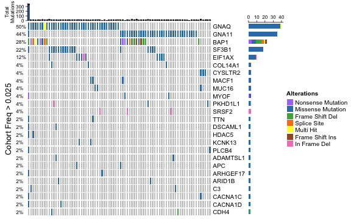

```r
library(MAFDash)
library(maftools)
maf <- system.file("extdata", "test.mutect2.maf.gz", package = "MAFDash")
generateOncoPlot(read.maf(maf))
```

```
#> -Reading
#> -Validating
#> -Silent variants: 561
#> -Summarizing
#> --Possible FLAGS among top ten genes:
#>   MACF1
#>   MUC16
#> -Processing clinical data
#> --Missing clinical data
#> -Finished in 0.241s elapsed (0.219s cpu)
```

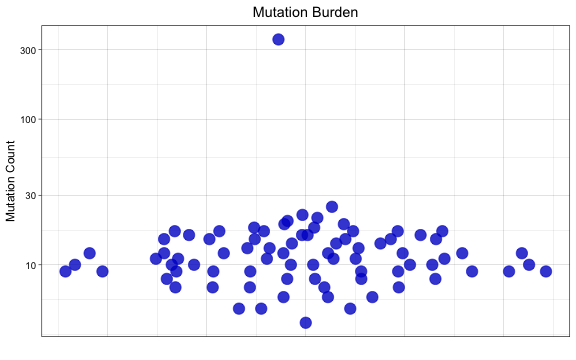

```r
library(MAFDash)
library(maftools)
maf <- system.file("extdata", "test.mutect2.maf.gz", package = "MAFDash")
generateBurdenPlot(read.maf(maf), plotType="Dotplot")
```

```
#> -Reading
#> -Validating
#> -Silent variants: 561
#> -Summarizing
#> --Possible FLAGS among top ten genes:
#>   MACF1
#>   MUC16
#> -Processing clinical data
#> --Missing clinical data
#> -Finished in 0.555s elapsed (0.536s cpu)
```

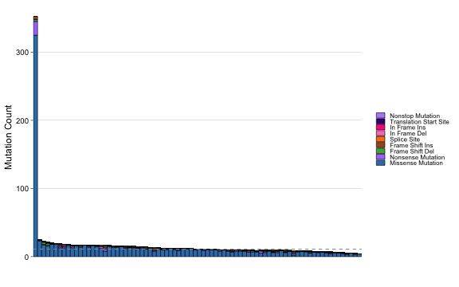

```r
generateBurdenPlot(read.maf(maf), plotType="Barplot")
```

```
#> -Reading
#> -Validating
#> -Silent variants: 561
#> -Summarizing
#> --Possible FLAGS among top ten genes:
#>   MACF1
#>   MUC16
#> -Processing clinical data
#> --Missing clinical data
#> -Finished in 0.198s elapsed (0.182s cpu)
```

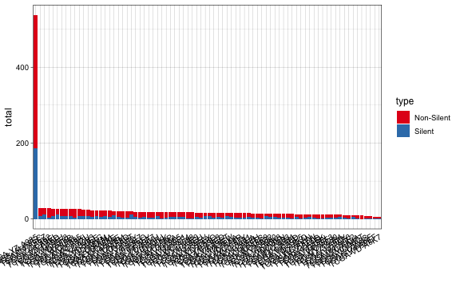

```r
library(MAFDash)
library(maftools)
maf <- system.file("extdata", "test.mutect2.maf.gz", package = "MAFDash")
generateMutationTypePlot(read.maf(maf))
```

# Adding Custom Plots

The `getMAFDashboard()` function will accept a named list for adding arbitrary objects to the dashboard. Each item in the list will be displayed in separate tabs, and the name of the element will be used as the title of the tab.

Elements of the list can be:

- **A boolean value**: indicates whether or not to draw one of the preset plots provided by MAFDasoh
- **A file path**: any image format (or PDF)
- **An R plot object**: ggplot, plotly, ComplexHeatmap

This functionality can be used with or without providing a MAF file. When MAF data is not provided, the “Variant Table” tab of the dashboard is automatically omitted.

## Toy example with `iris` data

```r
library(ggplot2)
library(plotly)
library(ComplexHeatmap)

data(iris)

## Simple ggplot
myplot <- ggplot(iris) + geom_point(aes(x=Sepal.Length, y=Sepal.Width, color=Species))

## Save as PNG (provide absolute file path)
mycustomimage_png <- file.path(getwd(),"custom_ggplot.png")
ggsave(mycustomimage_png, plot=myplot, width=5, height=4)

## Save as PDF (provide absolute file path)
mycustomimage_pdf <- file.path(getwd(),"custom_ggplot.pdf")
ggsave(mycustomimage_pdf, plot=myplot, width=5, height=4)

## Convert ggplot to plotly
myplotly <- ggplotly(myplot)

## Make heatmap with ComplexHeatmap
hmdata <- t(iris[,1:4])
hmanno <- HeatmapAnnotation(df=data.frame(Species=iris[,5]))
myhm <- Heatmap(hmdata, bottom_annotation = hmanno)

## Customizable plotly from https://github.com/mtandon09/Dynamic_Plotly
source("https://raw.githubusercontent.com/mtandon09/Dynamic_Plotly/master/make_cutomizable_plotly.R")
custom_plotly <- make_customizable_plotly(iris)

## Put together objects/filepaths into a list
toyplotlist <- list("ggplot"= myplot,
                   "plotly"= myplotly,
                   "PNG"= mycustomimage_png,
                   "PDF"= mycustomimage_pdf,
                   "ComplexHeatmap"= myhm,
                   "Customizable"= custom_plotly
)

## Filename to output to
html_filename="toy_dash.html"

## Render dashboard
getMAFDashboard(plotList = toyplotlist,
                outputFileName = html_filename,
                outputFileTitle = "Iris")
```

**Output** The output can be seen [here](https://mtandon09.github.io/MAFDashRPackage/examples/toy_dash.html.MAFDash.html).

#Advanced Example

## Download TCGA data

### Download MAF file using `TCGABiolinks`

MAFDash provides a wrapper function that tries to simplify retrieving data using `TCGABiolinks`. Valid project codes can be viewed by running `TCGABiolinks::getGDCprojects()` and checking the “tumor” column.

```r
library(MAFDash)
library(TCGABiolinks)

tcga_code = "UVM"    ## Uveal Melanoma
caller = "mutect2"
title_label = paste0("TCGA-",tcga_code)

maf_file <- getMAFdataTCGA(tcga_code,variant_caller = caller)
```

### Download clinical data using `TCGABiolinks`

```r
tcga_clinical <- TCGAbiolinks::GDCquery_clinic(project = paste0("TCGA-",tcga_code), type = "clinical")
tcga_clinical$Tumor_Sample_Barcode <- tcga_clinical$submitter_id
```

## Make a customized oncoplot

### Filter data

The `filterMAF` function can be used to filter the MAF data in various ways. Importantly, by default, it will remove commonly occurring mutations that are often considered to be false position ( [FLAG genes](https://bmcmedgenomics.biomedcentral.com/articles/10.1186/s12920-014-0064-y) )

```r
filtered_mafdata <- filterMAF(maf_file)
```

### Add clinical data

The easiest way to add clinical annotations to the oncoplot is to add clinical data to the `clinical.data` slot of a `MAF` object before passing it to the `generateOncoplot()` function.

MAFDash also provides a function that defines reasonable colors for some common clinical annotations provided with TCGA datasets.

```r
filtered_maf <- read.maf(filtered_mafdata, clinicalData = tcga_clinical)
annotation_colors <- getTCGAClinicalColors(ageRange = range(tcga_clinical$age_at_diagnosis, na.rm=T))
```

### Make an annotated oncoplot

The `add_clinical_annotations` argument can be:

- A boolean indicating whether or not to add annotations built from the `clinical.data` slot of the `MAF` object. Columns with all missing values are ignored. Maximum number of annotations plotted is 10 (first 10 non-empty columns of `clinical.data`)
- A character vector of column names provided as clinical data

```r
custom_onco <- generateOncoPlot(filtered_maf,
                                add_clinical_annotations = names(annotation_colors),
                                clin_data_colors = annotation_colors)
```

## Make some other figures

### TCGA Comparison

A lot of `maftools`'s plots are base graphics, so they're drawn to a device and not returned. But we can simply save them to a file and provide the file path.

```r
library(maftools)
tcgacompare_file <- file.path(getwd(),"tcga_compare.png")
png(tcgacompare_file,width=8, height=6, units="in", res=400)
tcgaCompare(filtered_maf,tcga_capture_size = NULL)
dev.off()
```

### Chord Diagram of mutation co-occurrence

This function is built on top of `maftools`'s `somaticInteractions()` function. It's just a different way of visualizing co-occurence or mutual exclusivity between genes.

```r
ribbonplot_file <- file.path(getwd(),"ribbon.pdf")
generateRibbonPlot(filtered_maf,save_name = ribbonplot_file)
```

## Render the dashboard

```r
customplotlist <- list("summary_plot"=T,
                       "burden"=T,
                       "TCGA Comparison"=tcgacompare_file,
                       "oncoplot"=T,
                       "Annotated Oncoplot"=custom_onco
                       )

## Filename to output to; if output directory doesn't exist, it will be created
html_filename=file.path("examples/TCGA-UVM.custom.mafdash.html")

## Render dashboard
getMAFDashboard(MAFfilePath = filtered_maf,
                plotList = customplotlist,
                outputFileName = html_filename,
                outputFileTitle = "Customized Dashboard")
```

## Output

The output can be seen [here](https://mtandon09.github.io/MAFDashRPackage/examples/TCGA-UVM.custom.mafdash.html.MAFDash.html).